# heat map

## 1 Introduction

Email from Baydoun, May Ahmad on Aug 1, 2023.

**Instructions in May’s email**

I hope you are doing well and enjoying the summer. I would like to invite you to contribute to a new UKB manuscript that we are now working on. I just completed and reviewed the analysis and typed most of the Tables. I am attaching some of the Figures I have. I wanted to see if you could re-do the left hand side heatmap in Figure 3 (See powerpoint) using the new excel sheet that I am attaching here. This is very similar to the previous paper, but instead of hospital-treated infections we are looking at periodontal disease. There are many results in common, which is very interesting, including GDF-15 being among the top hits with highly significant mediation! In this case, there are 18 top hits for proteins strongly related to the exposure (periodontal disease), but only a few are real mediators between periodontal disease and all-cause dementia.

## 2 Load data

```r
# d <- read_excel("../File_from_May/TOP22_FOURWAYDECOMPOSITION_FINDINGS_FINAL.xlsx", sheet = "HEATMAP_DATA") |>
d <- read_excel(here("heatmap/file_from_May/DATASHEET1_TOP18_FOURWAYDECOMPOSITION_FINDINGS_FINAL.xlsx"), sheet = "TOP 18 HITS") |>
  janitor::clean_names() |>
  mutate(p = as.numeric(p))


glimpse(d)
```

```
Rows: 162
Columns: 8
$ fourwaydecomp <chr> "tereri", "ereri_cde", "ereri_intref", "ereri_intmed", "…
$ beta          <dbl> 0.15027480, 0.10331430, -0.00693940, 0.06051570, -0.0066…
$ se            <dbl> 0.0818423, 0.0852672, 0.0048501, 0.0314724, 0.0180913, N…
$ z             <dbl> 1.84, 1.21, -1.43, 1.92, -0.37, NA, NA, NA, NA, 1.59, 1.…
$ p             <dbl> 0.066, 0.226, 0.152, 0.055, 0.715, NA, NA, NA, NA, 0.112…
$ lcl           <dbl> -0.0101332, -0.0638062, -0.0164454, -0.0011691, -0.04207…
$ ucl           <dbl> 0.3106828, 0.2704349, 0.0025667, 0.1222004, 0.0288424, N…
$ protein       <chr> "odam", "odam", "odam", "odam", "odam", "odam", "odam", …
```

## 3 data reorganizing

### 3.1 Convert to wide format

beta value

```r
d_wide <-
  d |>
  select(fourwaydecomp, beta, protein, p) |>
  pivot_wider(
    id_cols = protein,
    # id_cols = c(protein, p),
    names_from = fourwaydecomp,
    values_from = beta
  )

glimpse(d_wide)
```

```
Rows: 18
Columns: 10
$ protein      <chr> "odam", "cxcl17", "wfdc2", "gdf15", "cd83", "il19", "mmp1…
$ tereri       <dbl> 0.1502748, 0.1282669, 0.1429770, 0.1934880, 0.1502340, 0.…
$ ereri_cde    <dbl> 0.1033143, 0.1307410, 0.1037381, 0.1452248, 0.1063310, 0.…
$ ereri_intref <dbl> -0.0069394, -0.0110405, 0.0000401, -0.0046028, 0.0070835,…
$ ereri_intmed <dbl> 0.0605157, 0.0303836, 0.0028058, -0.0010693, 0.0344013, -…
$ ereri_pie    <dbl> -0.0066158, -0.0218172, 0.0363930, 0.0539354, 0.0024182, …
$ pct_cde      <dbl> 68.75025, 101.92887, 72.55580, 75.05623, 70.77692, 89.272…
$ pct_intref   <dbl> -4.61780684, -8.60744276, 0.02804647, -2.37885554, 4.7149…
$ pct_intmed   <dbl> 40.2700253, 23.6877947, 1.9624135, -0.5526441, 22.8984784…
$ pct_pie      <dbl> -4.402468, -17.009221, 25.453744, 27.875320, 1.609622, 14…
```

p value

```r
d_wide_p <-
  d |>
      mutate(
      p_anno = case_when(
         p <= 0.001 ~ "***",
         p <= 0.01 ~ "**",
         p <= 0.05 ~ "*",
         .default = ""
      )
   ) |>
  select(fourwaydecomp, beta, protein, p_anno) |>
  pivot_wider(
    id_cols = protein,
    # id_cols = c(protein, p),
    names_from = fourwaydecomp,
    values_from = p_anno
  )

glimpse(d_wide_p)
```

```
Rows: 18
Columns: 10
$ protein      <chr> "odam", "cxcl17", "wfdc2", "gdf15", "cd83", "il19", "mmp1…
$ tereri       <chr> "", "", "", "*", "", "*", "*", "", "", "", "*", "", "", "…
$ ereri_cde    <chr> "", "", "", "", "", "", "", "", "", "", "*", "", "", "*",…
$ ereri_intref <chr> "", "", "", "", "", "", "", "", "", "", "", "", "", "", "…
$ ereri_intmed <chr> "", "*", "", "", "**", "", "", "", "", "", "", "", "", ""…
$ ereri_pie    <chr> "", "*", "***", "***", "", "***", "*", "", "", "", "", ""…
$ pct_cde      <chr> "", "", "", "", "", "", "", "", "", "", "", "", "", "", "…
$ pct_intref   <chr> "", "", "", "", "", "", "", "", "", "", "", "", "", "", "…
$ pct_intmed   <chr> "", "", "", "", "", "", "", "", "", "", "", "", "", "", "…
$ pct_pie      <chr> "", "", "", "", "", "", "", "", "", "", "", "", "", "", "…
```

### 3.2 Convert to matrix

beta

```r
# Convert to matrix
mat <-
  d_wide |>
  select(- contains("pct_")) |>
  column_to_rownames("protein") |>
  as.matrix()

# Order the columns by their means
mat <- mat[, order(colMeans(mat), decreasing = TRUE)]

glimpse(mat)
```

```
 num [1:18, 1:5] 0.15 0.128 0.143 0.193 0.15 ...
 - attr(*, "dimnames")=List of 2
  ..$ : chr [1:18] "odam" "cxcl17" "wfdc2" "gdf15" ...
  ..$ : chr [1:5] "tereri" "ereri_cde" "ereri_pie" "ereri_intmed" ...
```

p value

```r
# Convert to matrix
mat_p <-
  d_wide_p |>
  select(- contains("pct_")) |>
  column_to_rownames("protein") |>
  as.matrix()

# Order the columns according to mat
mat_p <- mat_p[, colnames(mat)]

glimpse(mat_p)
```

```
 chr [1:18, 1:5] "" "" "" "*" "" "*" "*" "" "" "" "*" "" "" "*" "*" "*" "" ...
 - attr(*, "dimnames")=List of 2
  ..$ : chr [1:18] "odam" "cxcl17" "wfdc2" "gdf15" ...
  ..$ : chr [1:5] "tereri" "ereri_cde" "ereri_pie" "ereri_intmed" ...
```

## 4 Heatmap

### 4.1 Row ordering

```r
# o1 = seriate(dist(mat), method = "OLO")
# o1 = seriate(dist(mat), method = "MDS")
o1 = seriate(dist(mat), method = "MDS_angle")
```

### 4.2 Use full names as matrix column names

```r
# abbr. name = full name
ef_name <- c("tereri" = "total effect",
             "ereri_cde" = "controlled direct effect",
             "ereri_pie" = "pure indirect effect",
             "ereri_intmed" = "mediated interaction",
             "ereri_intref" = "interaction reference")

colnames(mat) <-  ef_name[colnames(mat)]
```

### 4.3 Make heatmap

- p value annotation.
  - p <= 0.05: *
  - p <= 0.01: **
  - p <= 0.001: ***

#### Scheme I

- Color: RColorBrewer, RdYlBu

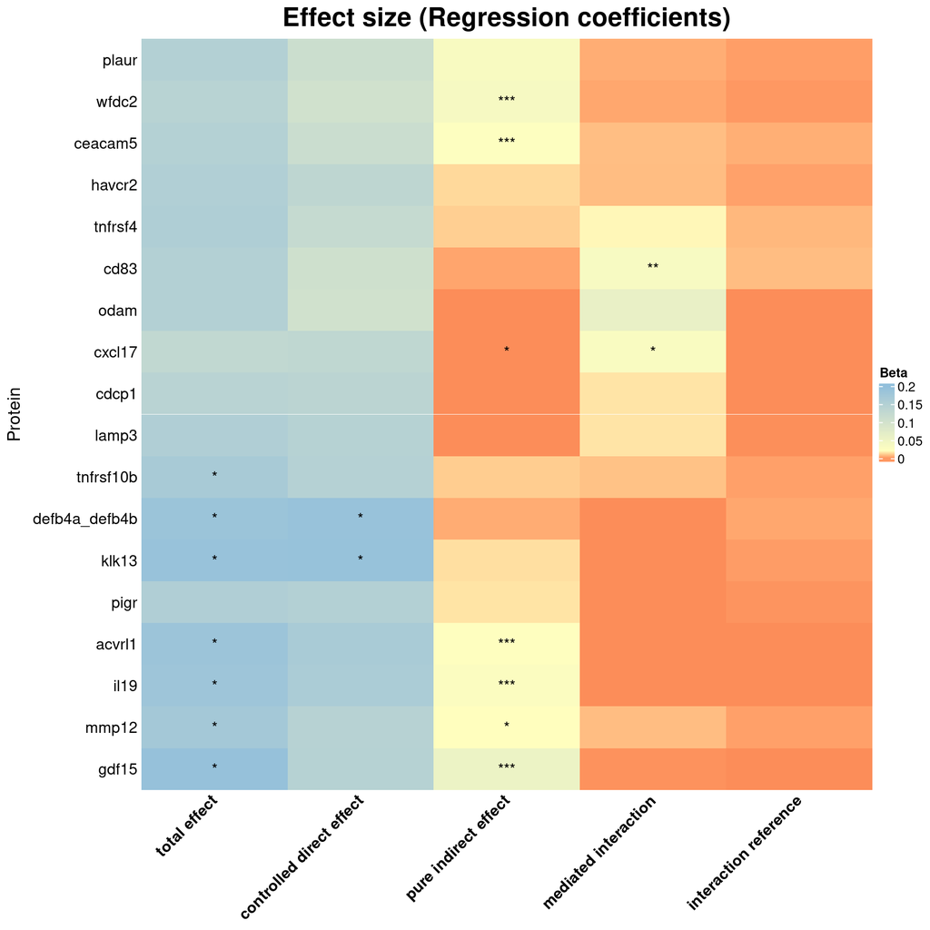

```r
# col_fun = colorRamp2(c(-2, 0.1, 2), brewer.pal(3, "RdYlBu"))
# brewer.pal(3, "RdYlBu") |>
#    scales::show_col()
# col_fun = colorRamp2(c(-0.002, 0.2, 1.3), brewer.pal(3, "RdYlBu"))
col_fun = colorRamp2(c(-0.002, 0.02, 0.2), brewer.pal(3, "RdYlBu"))

mat |>
  Heatmap(
   name = "Beta",
   cluster_columns = FALSE,
   cluster_rows = FALSE,
   row_order = get_order(o1),

   # color function
   col = col_fun,

   # Title
   row_title = "Protein",
   row_title_side = "left",
   column_title = "Effect size (Regression coefficients)",
   column_title_gp = gpar(fontsize = 20, fontface = "bold"),

   # Names
   row_names_side = "left",
   column_names_gp = gpar(fontsize = 12, fontface="bold"),
   column_names_rot = 45,

   # Add "*" for significant p values
   cell_fun = function(j, i, x, y, w, h, col) { # add text to each grid
        grid.text(mat_p[i, j], x, y)
    }
  )
```

#### Scheme II

- Color: scales::hue

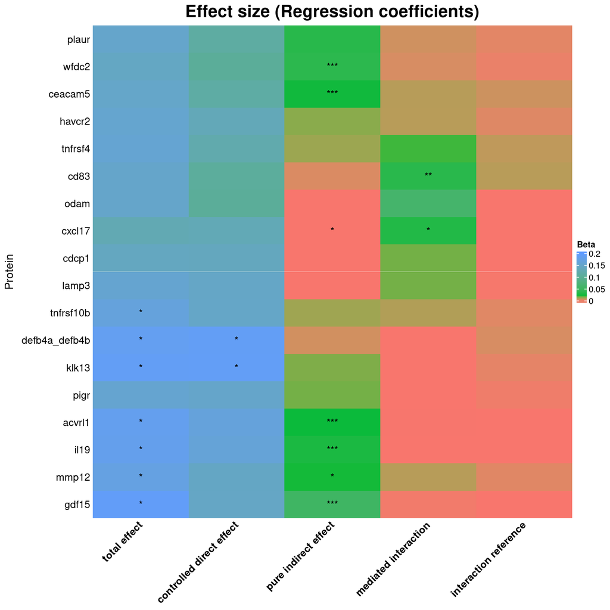

```r
# col_fun = colorRamp2(c(-0.002, 0.02, 0.2), brewer.pal(3, "RdYlBu"))
col_fun = colorRamp2(c(-0.002, 0.02, 0.2), scales::hue_pal()(3))
# col_fun = colorRamp2(c(-0.02, 0.3, 1.3), brewer.pal(3, "RdYlBu"))

mat |>
  Heatmap(
   name = "Beta",
   cluster_columns = FALSE,
   cluster_rows = FALSE,
   row_order = get_order(o1),

   # color function
   col = col_fun,

   # Title
   row_title = "Protein",
   row_title_side = "left",
   column_title = "Effect size (Regression coefficients)",
   column_title_gp = gpar(fontsize = 20, fontface = "bold"),

   # Names
   row_names_side = "left",
   column_names_gp = gpar(fontsize = 12, fontface="bold"),
   column_names_rot = 45,

   # Add "*" for significant p values
   cell_fun = function(j, i, x, y, w, h, col) { # add text to each grid
        grid.text(mat_p[i, j], x, y)
    }
  )
```

#### Scheme III

- Color: viridis

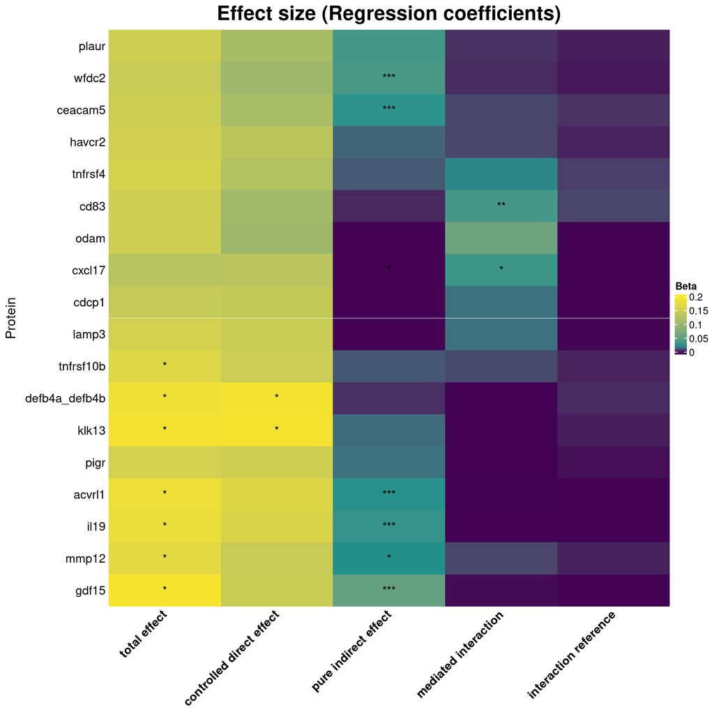

```r
col_fun = colorRamp2(c(-0.002, 0.02, 0.2), viridis(n=3, option = "D"))

mat |>
  Heatmap(
   name = "Beta",
   cluster_columns = FALSE,
   cluster_rows = FALSE,
   row_order = get_order(o1),

   # color function
   col = col_fun,

   # Title
   row_title = "Protein",
   row_title_side = "left",
   column_title = "Effect size (Regression coefficients)",
   column_title_gp = gpar(fontsize = 20, fontface = "bold"),

   # Names
   row_names_side = "left",
   column_names_gp = gpar(fontsize = 12, fontface="bold"),
   column_names_rot = 45,

   # Add "*" for significant p values
   cell_fun = function(j, i, x, y, w, h, col) { # add text to each grid
        grid.text(mat_p[i, j], x, y)
    }
  )
```